# DataAnalysis_VCF

1．パッケージの読込み

```r
rm(list=ls())

suppressWarnings(suppressMessages(library(sf)))
suppressWarnings(suppressMessages(library(tidyverse)))
suppressWarnings(suppressMessages(library(dplyr)))
suppressWarnings(suppressMessages(library(raster)))
suppressWarnings(suppressMessages(library(mapview)))
suppressWarnings(suppressMessages(library(exactextractr)))
suppressWarnings(suppressMessages(library(broom)))
suppressWarnings(suppressMessages(library(modelsummary)))
suppressWarnings(suppressMessages(library(estimatr)))
suppressWarnings(suppressMessages(library(did)))
#suppressWarnings(suppressMessages(library(table1)))
#suppressWarnings(suppressMessages(library(gtsummary)))
suppressWarnings(suppressMessages(library(flextable)))


#library(kableExtra)    # For pretty tables
#library(patchwork)     # For combining plots
#library(scales)        # For nice formatting functions
```

使用する森林データごとに、ロング形式のパネルデータ化⇒分析のプロセスを取る。

このため、使用する森林データごとにデータ変換⇒分析のプロセスを経なければならいということ。

1．VCF（Terra Vegetation Continuous Fields Yearly Global 250m）の分析

```r
#全変数の入ったデータの読込み（ワイド形式）
alldata_wide <- read_csv("./alldata_wide.csv")
#ワイド形式のままでの変数名調整、変数選択
data_VCF_wide <- alldata_wide %>%
  mutate(
    #forest_*の変数名統一
    forest_2000 = vcf_fr_2000,
    forest_2010 = vcf_fr_2010,
    forest_2020 = vcf_fr_2020,
    #vege_*の変数名統一（ロング化するためにアンダースコアは１つにする）
    vege_2000 = vcf_nf_2000,
    vege_2010 = vcf_nf_2010,
    vege_2020 = vcf_nf_2020,
    #pop_*の変数名統一（2000年以降はWorldPopを使う）
    pop_1975 = ghs_po_1975,
    pop_1990 = ghs_po_1990,
    pop_2000 = wdp_po_2000,
    pop_2010 = wdp_po_2010,
    pop_2020 = wdp_po_2020


    # anytreat = jp_any,


  ) %>%
  dplyr::select(starts_with(c("GID", "NAME",
                              "forest", "vege",
                              "prec", "tmmx", "tmmn",
                              "pop", "ntl",
                              "jptreat",
                              "wbtreat",
                              "jpwbtreat",
                              "jp_all", "wb_all",
                              "jpwb_all",
                              "jp_1st", "wb_1st",
                              "jpwb_1st",
                              "STjptreat",
                              "STwbtreat",
                              "STjpSTwbtreat",
                              "STjp_all", "STwb_all",
                              "STjpSTwb_all",
                              "STjp_1st", "STwb_1st",
                              "STjpSTwb_1st"
                              )
                            ,ignore.case = FALSE)
                )

#names(data_VCF_wide)

#ロング形式への変換
data_VCF_long <- data_VCF_wide %>%
  pivot_longer(-c(GID_2,
                  starts_with(c("NAME",
                              "jp_all",
                              "wb_all",
                              "jpwb_all",
                              "jp_1st",
                              "wb_1st",
                              "jpwb_1st",
                              "STjp_all",
                              "STwb_all",
                              "STjpSTwb_all",
                              "STjp_1st",
                              "STwb_1st",
                              "STjpSTwb_1st"
                              ))
                  ),
               names_to=c(".value", "year"),names_sep = "_") %>%
  filter(year==1930 | year==1975 | year==2000 | year==2010 | year==2020) %>%
  mutate(
    ID_dist = as.numeric(as.factor(GID_2)),
    ID_state = as.numeric(as.factor(NAME_1.x)),
    ID_stateyear = as.numeric(factor(paste0(ID_state, year))),
    pop = pop / 1000 , #元々は1000人単位、ここで100万人単位に切り替え
    lpop = log(pop),
    tmmx = tmmx / 10, #元々は0.1℃、ここで1℃単位に切り替え
    ltmmx = log(tmmx),
    tmmn = tmmn / 10, #同上
    ltmmn = log(tmmn),
    lprec = log(prec)
         )
#class(data_VCF_long$ID_stateyear)
```

分析

記述統計

```r
sumdata <- data_VCF_long %>%
  dplyr::select(starts_with(
    c("jpwb_all_tr", "year", "forest",
      "prec", "tm", "pop", "vege", "ntl")
    )) %>%
  mutate(treat = ifelse(jpwb_all_tr==1, "Treatment", "Control")) %>%
  filter(year==1975 | year==2000 | year==2020)

## datasummary_balance
## datasummary
sumtable <- datasummary( (forest + prec + tmmx + tmmn + pop + vege + ntl) *
                 (mean + sd )  + N + Percent()
               ~ year * treat ,
               data = sumdata,
               #output = "default"
               #output = "sumtable.html"
               #output = "sumtable.docx"
               output = 'data.frame'
               )

write.csv(sumtable,"sumtable.csv")
```

トレンド図

```r
#data_VCF_long$anytreat <- data_VCF_long$jp_all_tr
#data_VCF_long$anytreat <- data_VCF_long$STjp_all_tr
#data_VCF_long$anytreat <- data_VCF_long$wb_all_tr
data_VCF_long$anytreat <- data_VCF_long$jpwb_all_tr

(
 summary_VCF <- data_VCF_long %>%
  filter(year==1930 | year==1975 | year==2000 | year==2020) %>%
  mutate(Group = ifelse(anytreat==1, "Treatment", "Control")) %>%
  group_by(Group, year) %>%
  summarize(av_forest = mean(forest),
            sd_forest = sd(forest),
            n = n(),
            se = sd_forest / sqrt(n),
            ci95 = se * qt(.975, n - 1)
            )
)
```

```
## # A tibble: 8 x 7
## # Groups:   Group [2]
##   Group     year  av_forest sd_forest     n    se  ci95
##   <chr>     <chr>     <dbl>     <dbl> <int> <dbl> <dbl>
## 1 Control   1930       39.1      34.0   170 2.61   5.15
## 2 Control   1975       32.5      31.7   170 2.43   4.80
## 3 Control   2000       20.6      20.3   170 1.55   3.07
## 4 Control   2020       23.2      18.9   170 1.45   2.86
## 5 Treatment 1930       27.4      28.5   496 1.28   2.52
## 6 Treatment 1975       19.2      21.8   496 0.977  1.92
## 7 Treatment 2000       12.0      12.0   496 0.540  1.06
## 8 Treatment 2020       16.6      11.8   496 0.531  1.04
```

```r
summary(summary_VCF)
```

```
##     Group               year             av_forest       sd_forest
##  Length:8           Length:8           Min.   :12.03   Min.   :11.83
##  Class :character   Class :character   1st Qu.:18.53   1st Qu.:17.15
##  Mode  :character   Mode  :character   Median :21.89   Median :21.02
##                                        Mean   :23.82   Mean   :22.38
##                                        3rd Qu.:28.64   3rd Qu.:29.34
##                                        Max.   :39.11   Max.   :34.02
##        n             se              ci95
##  Min.   :170   Min.   :0.5311   Min.   :1.043
##  1st Qu.:170   1st Qu.:0.8679   1st Qu.:1.705
##  Median :333   Median :1.3642   Median :2.687
##  Mean   :333   Mean   :1.4217   Mean   :2.803
##  3rd Qu.:496   3rd Qu.:1.7743   3rd Qu.:3.503
##  Max.   :496   Max.   :2.6092   Max.   :5.151
```

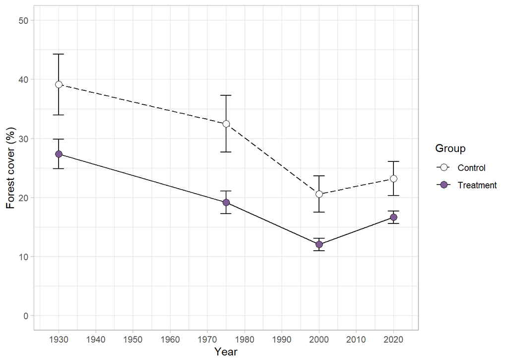

```r
summary_VCF$year = as.numeric(summary_VCF$year)



summary_VCF %>%
#  filter(year != 2010) %>%
  ggplot(., aes(x = year, y = av_forest, group = Group, fill = Group)) +
#  annotate("segment",x=1990,xend=2020,y=45,yend=45,colour="darkgreen",
#             size=0.5,arrow=arrow(length=unit(0.20,"cm")))+
#  annotate("rect",xmin=1990,xmax=Inf,ymin=,ymax=Inf,
#           alpha=.5,fill="#FB9A99")+
#  annotate("rect",xmin=1979,xmax=Inf,ymin=-Inf,ymax=45,
#           alpha=.5,fill="#A6CEE3")+
#  geom_text(x=2005,y=41,label="Intervention", alpha=.1,
#            colour="darkgreen",size=5)+
  geom_line(aes(linetype = Group)) +
  scale_linetype_manual(values = c("longdash", "solid")) +
  geom_errorbar(aes(ymax = av_forest + ci95, ymin = av_forest - ci95), width = 3) +
  geom_point(size = 3, shape = 21) +
  ylim(0,50) +
  scale_x_continuous(breaks=seq(1930,2020,by=10),limits=c(1928, 2022))+
  labs(x="Year", y="Forest cover (%)")+
  scale_fill_manual(values = c("white", "#7F5B96"))+
  theme_light()
```

```r
#  theme_minimal()
```

1930年～1975年までのパラレルトレンドの検証

```r
#data_VCF_wide$anytreat <- data_VCF_wide$jp_all_tr
#data_VCF_wide$anytreat <- data_VCF_wide$wb_all_tr
data_VCF_wide$anytreat <- data_VCF_wide$jpwb_all_tr

#data_VCF_long$anytreat <- data_VCF_long$jp_all_tr
#data_VCF_long$anytreat <- data_VCF_long$wb_all_tr
data_VCF_long$anytreat <- data_VCF_long$jpwb_all_tr


data_VCF_wide_trend <- data_VCF_wide %>%
  dplyr::select(forest_1930, forest_1975, forest_2000, forest_2020, anytreat) %>%
  mutate(forest_dif7530 = forest_1975 - forest_1930,
         forest_dif0075 = forest_2000 - forest_1975,
         forest_dif2000 = forest_2020 - forest_2000,
         forest_dif2075 = forest_2020 - forest_1975,
         Group = ifelse(anytreat==1, "Treatment", "Control"))

trendtable <- data_VCF_wide_trend %>%
  group_by(Group) %>%
  summarize(av_forest_1930 = mean(forest_1930),
            #sd_forest_1930 = sd(forest_1930),
            av_forest_1975 = mean(forest_1975),
            av_forest_2000 = mean(forest_2000),
            av_forest_2020 = mean(forest_2020),
            av_forest_dif7530 = mean(forest_dif7530),
            av_forest_dif0075 = mean(forest_dif0075),
            av_forest_dif2000 = mean(forest_dif2000),
            av_forest_dif2075 = mean(forest_dif2075)
            ) %>%
  t() %>% as.data.frame()

names(trendtable) <- as.character(unlist(trendtable[1,]))
trendtable <- trendtable[-1,]

trendtable <- trendtable %>%
  mutate(Control = as.numeric(Control),
         Treatment = as.numeric(Treatment),
         Diff = Treatment - Control,
         pvalue = 1
         )


#t-test
table(data_VCF_wide_trend$anytreat)
```

```
##
##   0   1
## 170 496
```

```r
trendtable[1,4] <- t.test(forest_1930 ~ anytreat,
                          data = data_VCF_wide_trend)$p.value
trendtable[2,4] <- t.test(forest_1975 ~ anytreat,
                          data = data_VCF_wide_trend)$p.value
trendtable[3,4] <- t.test(forest_2000 ~ anytreat,
                          data = data_VCF_wide_trend)$p.value
trendtable[4,4] <- t.test(forest_2020 ~ anytreat,
                          data = data_VCF_wide_trend)$p.value
trendtable[5,4] <- t.test(forest_dif7530 ~ anytreat,
                          data = data_VCF_wide_trend)$p.value
trendtable[6,4] <- t.test(forest_dif0075 ~ anytreat,
                          data = data_VCF_wide_trend)$p.value
trendtable[7,4] <- t.test(forest_dif2000 ~ anytreat,
                          data = data_VCF_wide_trend)$p.value
t.test(forest_dif2000 ~ anytreat,
                          data = data_VCF_wide_trend)
```

```
##
##  Welch Two Sample t-test
##
## data:  forest_dif2000 by anytreat
## t = -7.3096, df = 305.74, p-value = 2.355e-12
## alternative hypothesis: true difference in means is not equal to 0
## 95 percent confidence interval:
##  -2.536349 -1.460417
## sample estimates:
## mean in group 0 mean in group 1
##        2.613212        4.611595
```

```r
trendtable[8,4] <- t.test(forest_dif2075 ~ anytreat,
                          data = data_VCF_wide_trend)$p.value

write.csv(trendtable,"trendtable.csv")

#
# #(1)1930年と1975年の２時点パネル分析
# model1 <- data_VCF_long %>%
#   filter(year == 1930 | year == 1975) %>%
#   lm(forest ~ anytreat + year + anytreat:year + GID_2,
#      data = .,)
#
# #(1)1930年と1975年の２時点パネル分析
# model2 <- data_VCF_wide %>%
#   mutate(forest_d3075 = forest_1975 - forest_1930) %>%
#   lm(forest_d3075 ~ anytreat,
#      data = .,)
#
#
# #分析結果をlistにしてmsummaryで表示
# reglist <- list()
# reglist[["model1"]] <- model1
# reglist[["model2"]] <- model2
#
# msummary(reglist,
#          gof_omit = "AIC|BIC|Log.Lik.|se_type",
#          stars = c("*"=0.10, "**"=0.05, "***"=0.01),
#          coef_omit = "GID_2")
```

（１）通常の固定効果モデル

(1)1975年、2000年、2020年の３時点パネル分析

世銀と日本を集計

```r
#1975年と2000年の2期間、コントロールなし
model1 <- data_VCF_long %>%
  filter(year == 1975 | year == 2000) %>%
  lm_robust(forest ~ jpwbtreat,
            fixed_effects = ~ ID_dist + year,
            data = .,
            clusters = ID_dist, se_type = "stata")

#1975年と2000年の2期間、全てコントロール
model2 <- data_VCF_long %>%
  filter(year == 1975 | year == 2000) %>%
  lm_robust(forest ~ jpwbtreat + prec + tmmx + tmmn + pop,
            fixed_effects = ~ ID_dist + year,
            data = .,
            clusters = ID_dist, se_type = "stata")

#2000年と2020年の2期間、コントロールなし
model3 <- data_VCF_long %>%
  filter(year == 2000 | year == 2020) %>%
  lm_robust(forest ~ jpwbtreat,
            fixed_effects = ~ ID_dist + year,
            data = .,
            clusters = ID_dist, se_type = "stata")

#2000年と2020年の2期間、全てコントロール
model4 <- data_VCF_long %>%
  filter(year == 2000 | year == 2020) %>%
  lm_robust(forest ~ jpwbtreat + prec + tmmx + tmmn + pop + vege + ntl,
            fixed_effects = ~ ID_dist + year,
            data = .,
            clusters = ID_dist, se_type = "stata")

#1975年、2000年、2020年の３期間、コントロールなし
model5 <- data_VCF_long %>%
  filter(year == 1975 | year == 2000 | year == 2020) %>%
  lm_robust(forest ~ jpwbtreat,
            fixed_effects = ~ ID_dist + year,
            data = .,
            clusters = ID_dist, se_type = "stata")

#1975年、2000年、2020年の３期間、全てコントロール
model6 <- data_VCF_long %>%
  filter(year == 1975 | year == 2000 | year == 2020) %>%
  lm_robust(forest ~ jpwbtreat + prec + tmmx + tmmn + pop,
            fixed_effects = ~ ID_dist + year,
            data = .,
            clusters = ID_dist, se_type = "stata")


#分析結果をlistにしてmsummaryで表示
reglist <- list()
reglist[["model1"]] <- model1
reglist[["model2"]] <- model2
reglist[["model3"]] <- model3
reglist[["model4"]] <- model4
reglist[["model5"]] <- model5
reglist[["model6"]] <- model6
#reglist[["model7"]] <- model7
#reglist[["model8"]] <- model8

msummary(reglist,
         gof_omit = "AIC|BIC|Log.Lik.|se_type",
         stars = c("*"=0.10, "**"=0.05, "***"=0.01))
```

|  | model1 | model2 | model3 | model4 | model5 | model6 |
| --- | --- | --- | --- | --- | --- | --- |
| jpwbtreat | 9.783*** | 9.025*** | －0.552 | 0.072 | 6.510*** | 6.992*** |
|  | (1.817) | (2.425) | (0.490) | (0.396) | (1.308) | (1.322) |
| prec |  | 0.046 |  | 0.017*** |  | 0.013 |
|  |  | (0.049) |  | (0.005) |  | (0.017) |
| tmmx |  | －6.352** |  | －1.705*** |  | －5.453*** |
|  |  | (2.738) |  | (0.592) |  | (1.674) |
| tmmn |  | 8.788*** |  | －0.200 |  | 5.237*** |
|  |  | (2.249) |  | (0.577) |  | (1.548) |
| pop |  | 6.737*** |  | 0.310 |  | 3.793*** |
|  |  | (1.505) |  | (0.221) |  | (0.833) |
| vege |  |  |  | －0.293*** |  |  |
|  |  |  |  | (0.036) |  |  |
| ntl |  |  |  | －0.002 |  |  |
|  |  |  |  | (0.040) |  |  |
| Num.Obs. | 1332 | 1332 | 1332 | 1332 | 1998 | 1998 |
| R2 | 0.872 | 0.885 | 0.988 | 0.992 | 0.844 | 0.855 |
| R2 Adj. | 0.744 | 0.768 | 0.976 | 0.983 | 0.765 | 0.781 |

* p < 0.1, ** p < 0.05, *** p < 0.01

```r
regresult1 <- msummary(reglist,
         gof_omit = "AIC|BIC|Log.Lik.|se_type",
         stars = c("*"=0.10, "**"=0.05, "***"=0.01),
         output = 'data.frame')

write.csv(regresult1,"regresult1.csv")
```

(1)1975年、2000年、2020年の３時点パネル分析

世銀と日本を分割

```r
#1975年と2000年の2期間、コントロールなし
model1 <- data_VCF_long %>%
  filter(year == 1975 | year == 2000) %>%
  lm_robust(forest ~ wbtreat + jptreat,
            fixed_effects = ~ ID_dist + year,
            data = .,
            clusters = ID_dist, se_type = "stata")

#1975年と2000年の2期間、コントロールあり
model2 <- data_VCF_long %>%
  filter(year == 1975 | year == 2000) %>%
  lm_robust(forest ~ wbtreat + jptreat + prec + tmmx + tmmn + pop,
            fixed_effects = ~ ID_dist + year,
            data = .,
            clusters = ID_dist, se_type = "stata")

#2000年と2020年の2期間、コントロールなし
model3 <- data_VCF_long %>%
  filter(year == 2000 | year == 2020) %>%
  lm_robust(forest ~ wbtreat + jptreat,
            fixed_effects = ~ ID_dist + year,
            data = .,
            clusters = ID_dist, se_type = "stata")

#2000年と2020年の2期間、コントロールあり
model4 <- data_VCF_long %>%
  filter(year == 2000 | year == 2020) %>%
  lm_robust(forest ~ wbtreat + jptreat + prec + tmmx + tmmn + pop + vege + ntl,
            fixed_effects = ~ ID_dist + year,
            data = .,
            clusters = ID_dist, se_type = "stata")

#1975年、2000年、2020年の３期間、コントロールなし
model5 <- data_VCF_long %>%
  filter(year == 1975 | year == 2000 | year == 2020) %>%
  lm_robust(forest ~ wbtreat + jptreat ,
            fixed_effects = ~ ID_dist + year,
            data = .,
            clusters = ID_dist, se_type = "stata")

#1975年、2000年、2020年の３期間、コントロールあり
model6 <- data_VCF_long %>%
  filter(year == 1975 | year == 2000 | year == 2020) %>%
  lm_robust(forest ~ wbtreat + jptreat +prec + tmmx + tmmn + pop,
            fixed_effects = ~ ID_dist + year,
            data = .,
            clusters = ID_dist, se_type = "stata")


#分析結果をlistにしてmsummaryで表示
reglist <- list()
reglist[["model1"]] <- model1
reglist[["model2"]] <- model2
reglist[["model3"]] <- model3
reglist[["model4"]] <- model4
reglist[["model5"]] <- model5
reglist[["model6"]] <- model6
#reglist[["model7"]] <- model7
#reglist[["model8"]] <- model8

msummary(reglist,
         gof_omit = "AIC|BIC|Log.Lik.|se_type",
         stars = c("*"=0.10, "**"=0.05, "***"=0.01))
```

|  | model1 | model2 | model3 | model4 | model5 | model6 |
| --- | --- | --- | --- | --- | --- | --- |
| wbtreat | 6.920*** | 5.668*** | －1.804** | －0.998 | 5.821*** | 5.489*** |
|  | (1.700) | (1.929) | (0.884) | (0.626) | (1.392) | (1.356) |
| jptreat | 5.254*** | 5.985*** | 1.303*** | 1.300*** | 3.333*** | 4.232*** |
|  | (1.777) | (2.082) | (0.415) | (0.354) | (0.979) | (0.988) |
| prec |  | 0.046 |  | 0.018*** |  | 0.014 |
|  |  | (0.050) |  | (0.005) |  | (0.016) |
| tmmx |  | －6.365** |  | －1.797*** |  | －5.684*** |
|  |  | (2.856) |  | (0.589) |  | (1.706) |
| tmmn |  | 10.410*** |  | 0.021 |  | 5.766*** |
|  |  | (2.347) |  | (0.589) |  | (1.586) |
| pop |  | 7.132*** |  | 0.357* |  | 3.706*** |
|  |  | (1.557) |  | (0.215) |  | (0.848) |
| vege |  |  |  | －0.290*** |  |  |
|  |  |  |  | (0.034) |  |  |
| ntl |  |  |  | 0.009 |  |  |
|  |  |  |  | (0.041) |  |  |
| Num.Obs. | 1332 | 1332 | 1332 | 1332 | 1998 | 1998 |
| R2 | 0.869 | 0.884 | 0.988 | 0.992 | 0.844 | 0.855 |
| R2 Adj. | 0.737 | 0.765 | 0.977 | 0.984 | 0.766 | 0.781 |

* p < 0.1, ** p < 0.05, *** p < 0.01

```r
regresult2 <- msummary(reglist,
         gof_omit = "AIC|BIC|Log.Lik.|se_type",
         stars = c("*"=0.10, "**"=0.05, "***"=0.01),
         output = "data.frame")

write.csv(regresult2,"regresult2.csv")
```

Callaway (2020)のDID

1975、2000、2020の３時点パネル

```r
#data_VCF_long$firstyear <- data_VCF_long$jp_1sttreat
#data_VCF_long$firstyear <- data_VCF_long$wb_1sttreat
data_VCF_long$firstyear <- data_VCF_long$jpwb_1sttreat

data_VCF_long2 <- data_VCF_long %>%
  filter(year == 1975 | year == 2000 | year == 2020) %>%
  mutate(
    year = as.numeric(year),
    firsttreat = case_when(
          firstyear > 0 & firstyear < 2000 ~ 2000,
          firstyear >= 2000 ~ 2020,
          TRUE ~ 0
        )
    )

summary(data_VCF_long2)
```

```
##     GID_2             NAME_1.x           NAME_2.x           NAME_1.y
##  Length:1998        Length:1998        Length:1998        Length:1998
##  Class :character   Class :character   Class :character   Class :character
##  Mode  :character   Mode  :character   Mode  :character   Mode  :character
##
##
##
##
##    NAME_2.y           jp_all_num       jp_all_tr       jp_all_cost
##  Length:1998        Min.   :0.0000   Min.   :0.0000   Min.   :  0.00
##  Class :character   1st Qu.:0.0000   1st Qu.:0.0000   1st Qu.:  0.00
##  Mode  :character   Median :0.0000   Median :0.0000   Median :  0.00
##                     Mean   :0.6381   Mean   :0.4174   Mean   : 80.36
##                     3rd Qu.:1.0000   3rd Qu.:1.0000   3rd Qu.:128.20
##                     Max.   :4.0000   Max.   :1.0000   Max.   :423.00
##
##    wb_all_num       wb_all_tr       wb_all_cost      jpwb_all_num
##  Min.   :0.0000   Min.   :0.0000   Min.   :  0.00   Min.   :0.000
##  1st Qu.:0.0000   1st Qu.:0.0000   1st Qu.:  0.00   1st Qu.:0.000
##  Median :1.0000   Median :1.0000   Median : 33.00   Median :1.000
##  Mean   :0.9249   Mean   :0.5616   Mean   : 70.47   Mean   :1.563
##  3rd Qu.:1.0000   3rd Qu.:1.0000   3rd Qu.:124.00   3rd Qu.:3.000
##  Max.   :4.0000   Max.   :1.0000   Max.   :256.00   Max.   :6.000
##
##   jpwb_all_tr     jpwb_all_cost   jpwb_all_4type      jp_1sttreat
##  Min.   :0.0000   Min.   :  0.0   Length:1998        Min.   :   0.0
##  1st Qu.:0.0000   1st Qu.:  0.0   Class :character   1st Qu.:   0.0
##  Median :1.0000   Median :122.2   Mode  :character   Median :   0.0
##  Mean   :0.7447   Mean   :150.8                      Mean   : 836.4
##  3rd Qu.:1.0000   3rd Qu.:253.0                      3rd Qu.:1997.0
##  Max.   :1.0000   Max.   :588.0                      Max.   :2018.0
##
##   wb_1sttreat   jpwb_1sttreat   STjp_all_num     STjp_all_tr
##  Min.   :   0   Min.   :   0   Min.   :0.0000   Min.   :0.0000
##  1st Qu.:   0   1st Qu.:   0   1st Qu.:0.0000   1st Qu.:0.0000
##  Median :1979   Median :1983   Median :1.0000   Median :1.0000
##  Mean   :1116   Mean   :1483   Mean   :0.9805   Mean   :0.5165
##  3rd Qu.:1985   3rd Qu.:1995   3rd Qu.:2.0000   3rd Qu.:1.0000
##  Max.   :2018   Max.   :2018   Max.   :5.0000   Max.   :1.0000
##
```

[output cut: 57 more lines]

```
##  Min.   :-2.761   Min.   :-2.812   Min.   :1.910   Min.   :0.0000
##  1st Qu.: 3.390   1st Qu.: 2.904   1st Qu.:4.273   1st Qu.:0.0000
##  Median : 3.441   Median : 2.968   Median :4.577   Median :1.0000
##  Mean   : 3.367   Mean   : 2.899   Mean   :4.600   Mean   :0.7447
##  3rd Qu.: 3.474   3rd Qu.: 3.024   3rd Qu.:4.936   3rd Qu.:1.0000
##  Max.   : 3.571   Max.   : 3.264   Max.   :6.362   Max.   :1.0000
##  NA's   :4        NA's   :31
##    firstyear      firsttreat
##  Min.   :   0   Min.   :   0
##  1st Qu.:   0   1st Qu.:   0
##  Median :1983   Median :2000
##  Mean   :1483   Mean   :1492
##  3rd Qu.:1995   3rd Qu.:2000
##  Max.   :2018   Max.   :2020
##
```

```r
#hist(data_VCF_long2$pop)
#hist(data_VCF_long2$tmmx)

table(data_VCF_long2$firsttreat)
```

```
##
##    0 2000 2020
##  510 1215  273
```

```r
##### Unconditional: 説明変数なし
out_uncond <- att_gt(yname = "forest",
              gname = "firsttreat",
              idname = "ID_dist",
              tname = "year",
              #xformla = ~ 1,
              #xformla = ~ prec + tmmx + tmmn,
              #xformla = ~ lprec + lpop ,
              #est_method = "reg", #default = "dr"
              #control_group="notyettreated",

              data = data_VCF_long2
              )
summary(out_uncond)
```

```
##
## Call:
## att_gt(yname = "forest", tname = "year", idname = "ID_dist",
##     gname = "firsttreat", data = data_VCF_long2)
##
## Reference: Callaway, Brantly and Pedro H.C. Sant'Anna.  "Difference-in-Differences with Multiple Time Periods." Forthcoming at the Journal of Econometrics <https://arxiv.org/abs/1803.09015>, 2020.
##
## Group-Time Average Treatment Effects:
##  Group Time ATT(g,t) Std. Error [95% Simult.  Conf. Band]
##   2000 2000   7.4011     1.5343        3.7562     11.0460 *
##   2000 2020   9.6212     1.6478        5.7066     13.5358 *
##   2020 2000  -6.8317     2.0828      -11.7795     -1.8839 *
##   2020 2020   1.0114     0.3898        0.0853      1.9375 *
## ---
## Signif. codes: `*' confidence band does not cover 0
##
## P-value for pre-test of parallel trends assumption:  0.00147
## Control Group:  Never Treated,  Anticipation Periods:  0
## Estimation Method:  Doubly Robust
```

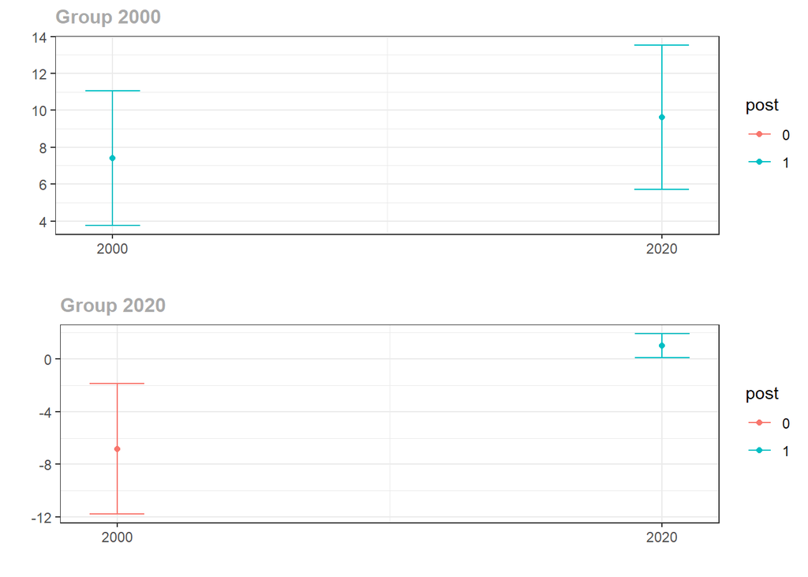

```r
ggdid(out_uncond)
```

```r
#Dynamic Effects and Event Studies
es_uncond <- aggte(out_uncond, type = "dynamic")
summary(es_uncond)
```

```
##
## Call:
## aggte(MP = out_uncond, type = "dynamic")
##
## Reference: Callaway, Brantly and Pedro H.C. Sant'Anna.  "Difference-in-Differences with Multiple Time Periods." Forthcoming at the Journal of Econometrics <https://arxiv.org/abs/1803.09015>, 2020.
##
##
## Overall ATT:
##    ATT Std. Error     [95%  Conf. Int.]
##  7.925     1.4424     5.098      10.752 *
##
##
## Dynamic Effects:
##  event time     ATT Std. Error [95% Simult.  Conf. Band]
##         -20 -6.8317     2.1558      -11.5579     -2.1054 *
##           0  6.2288     1.2410        3.5080      8.9495 *
##          20  9.6212     1.6085        6.0949     13.1475 *
## ---
## Signif. codes: `*' confidence band does not cover 0
##
## Control Group:  Never Treated,  Anticipation Periods:  0
## Estimation Method:  Doubly Robust
```

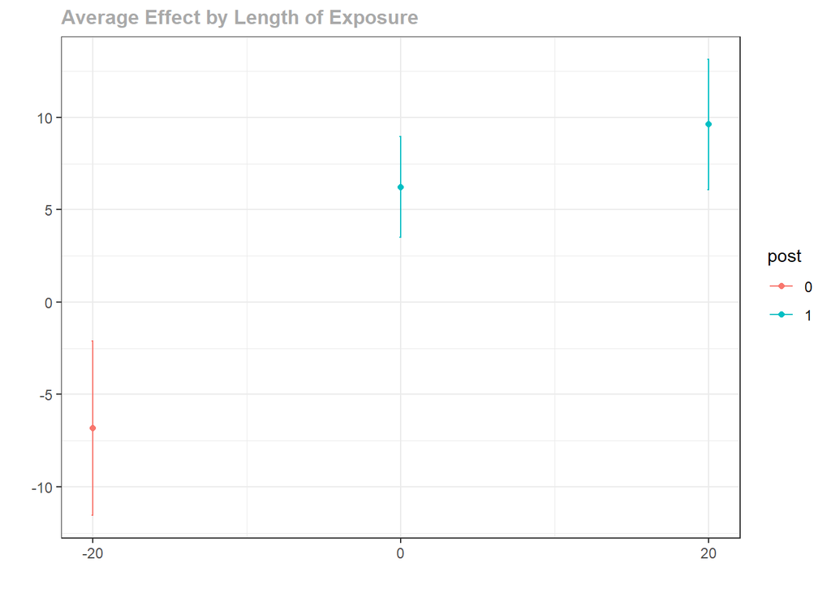

```r
ggdid(es_uncond)
```

```r
#Group-Specific Effects
gef_uncond <- aggte(out_uncond, type = "group")
summary(gef_uncond)
```

```
##
## Call:
## aggte(MP = out_uncond, type = "group")
##
## Reference: Callaway, Brantly and Pedro H.C. Sant'Anna.  "Difference-in-Differences with Multiple Time Periods." Forthcoming at the Journal of Econometrics <https://arxiv.org/abs/1803.09015>, 2020.
##
##
## Overall ATT:
##     ATT Std. Error     [95%  Conf. Int.]
##  7.1352     1.4564    4.2807      9.9897 *
##
##
## Group Effects:
##  group    ATT Std. Error [95% Simult.  Conf. Band]
##   2000 8.5111     1.6240        4.8389     12.1834 *
##   2020 1.0114     0.3959        0.1162      1.9065 *
## ---
## Signif. codes: `*' confidence band does not cover 0
##
## Control Group:  Never Treated,  Anticipation Periods:  0
## Estimation Method:  Doubly Robust
```

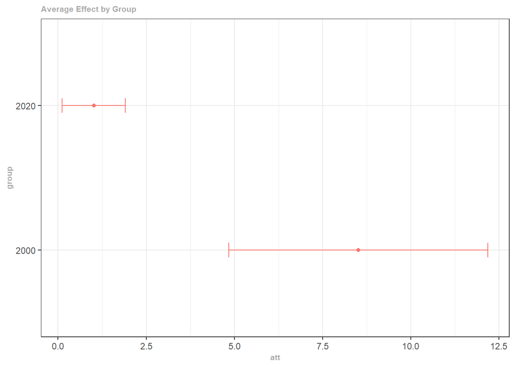

```r
ggdid(gef_uncond)
```

```r
##### Conditional: 説明変数あり
out_cond <- att_gt(yname = "forest",
              gname = "firsttreat",
              idname = "ID_dist",
              tname = "year",
              #xformla = ~ 1,
              xformla = ~ prec + tmmx + tmmn,
              #xformla = ~ lprec + lpop ,
              #est_method = "reg", #default = "dr"
              #control_group="notyettreated",

              data = data_VCF_long2
              )
summary(out_cond)
```

```
##
## Call:
## att_gt(yname = "forest", tname = "year", idname = "ID_dist",
##     gname = "firsttreat", xformla = ~prec + tmmx + tmmn, data = data_VCF_long2)
##
## Reference: Callaway, Brantly and Pedro H.C. Sant'Anna.  "Difference-in-Differences with Multiple Time Periods." Forthcoming at the Journal of Econometrics <https://arxiv.org/abs/1803.09015>, 2020.
##
## Group-Time Average Treatment Effects:
##  Group Time ATT(g,t) Std. Error [95% Simult.  Conf. Band]
##   2000 2000   6.7979     1.8882        2.3703     11.2255 *
##   2000 2020   8.7974     1.9974        4.1138     13.4810 *
##   2020 2000  -5.8134     2.2903      -11.1838     -0.4430 *
##   2020 2020   1.3332     0.3997        0.3959      2.2704 *
## ---
## Signif. codes: `*' confidence band does not cover 0
##
## P-value for pre-test of parallel trends assumption:  0.00794
## Control Group:  Never Treated,  Anticipation Periods:  0
## Estimation Method:  Doubly Robust
```

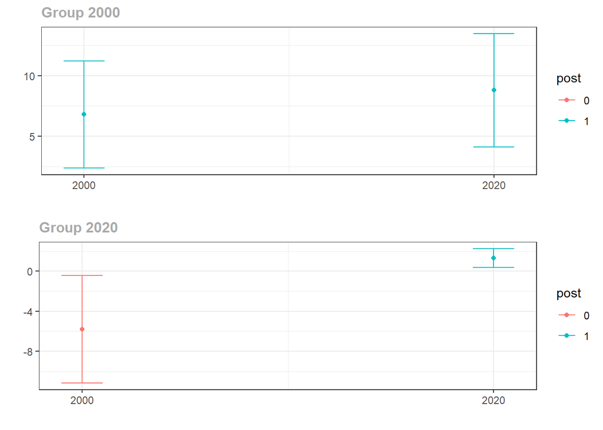

```r
ggdid(out_cond)
```

```r
#Dynamic Effects and Event Studies
es_cond <- aggte(out_cond, type = "dynamic")
summary(es_cond)
```

```
##
## Call:
## aggte(MP = out_cond, type = "dynamic")
##
## Reference: Callaway, Brantly and Pedro H.C. Sant'Anna.  "Difference-in-Differences with Multiple Time Periods." Forthcoming at the Journal of Econometrics <https://arxiv.org/abs/1803.09015>, 2020.
##
##
## Overall ATT:
##     ATT Std. Error     [95%  Conf. Int.]
##  7.2964     1.6834     3.997     10.5957 *
##
##
## Dynamic Effects:
##  event time     ATT Std. Error [95% Simult.  Conf. Band]
##         -20 -5.8134     2.2887      -10.9282     -0.6986 *
##           0  5.7953     1.6101        2.1971      9.3935 *
##          20  8.7974     1.9799        4.3726     13.2222 *
## ---
## Signif. codes: `*' confidence band does not cover 0
##
## Control Group:  Never Treated,  Anticipation Periods:  0
## Estimation Method:  Doubly Robust
```

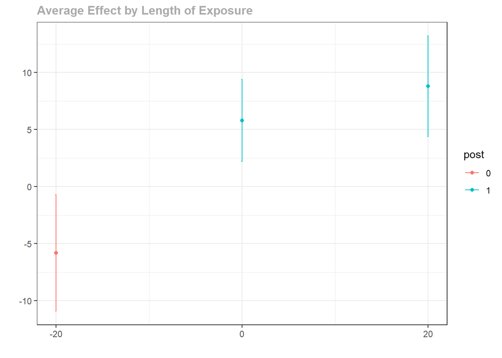

```r
ggdid(es_cond)
```

```r
#Group-Specific Effects
gef_cond <- aggte(out_cond, type = "group")
summary(gef_cond)
```

```
##
## Call:
## aggte(MP = out_cond, type = "group")
##
## Reference: Callaway, Brantly and Pedro H.C. Sant'Anna.  "Difference-in-Differences with Multiple Time Periods." Forthcoming at the Journal of Econometrics <https://arxiv.org/abs/1803.09015>, 2020.
##
##
## Overall ATT:
##     ATT Std. Error     [95%  Conf. Int.]
##  6.6116     1.5507    3.5722       9.651 *
##
##
## Group Effects:
##  group    ATT Std. Error [95% Simult.  Conf. Band]
##   2000 7.7977     1.9203        3.2954     12.3000 *
##   2020 1.3332     0.3867        0.4266      2.2397 *
## ---
## Signif. codes: `*' confidence band does not cover 0
##
## Control Group:  Never Treated,  Anticipation Periods:  0
## Estimation Method:  Doubly Robust
```

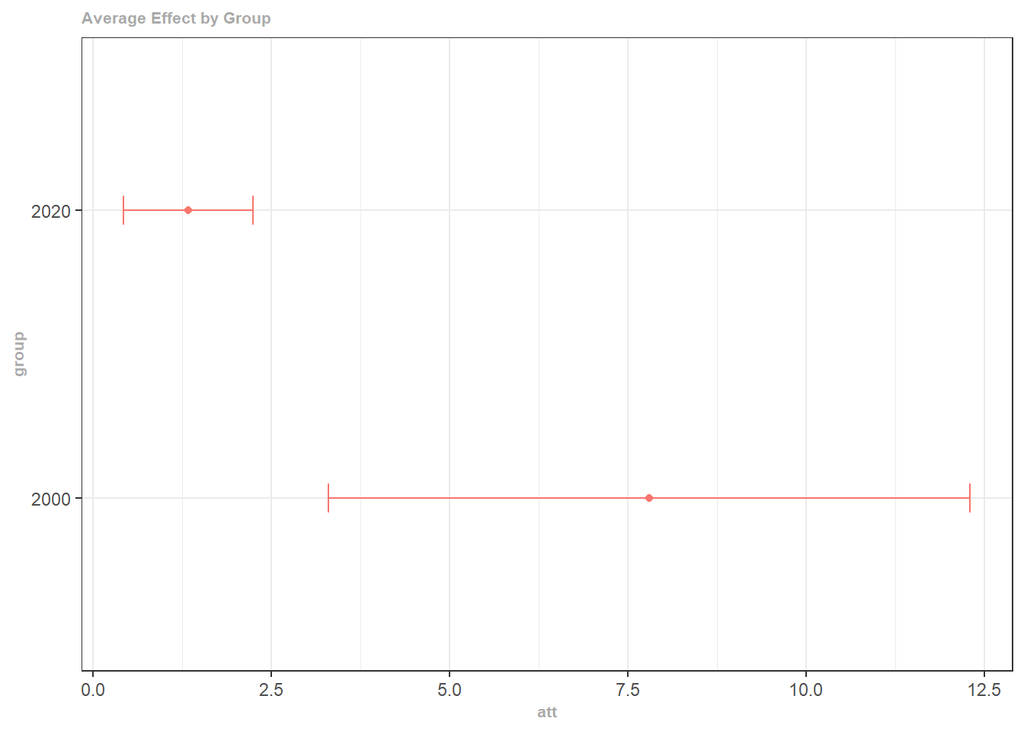

```r
ggdid(gef_cond)
```

```r
#Calendar Time Effects
cef_cond <- aggte(out_cond, type = "calendar")
summary(cef_cond)
```

```
##
## Call:
## aggte(MP = out_cond, type = "calendar")
##
## Reference: Callaway, Brantly and Pedro H.C. Sant'Anna.  "Difference-in-Differences with Multiple Time Periods." Forthcoming at the Journal of Econometrics <https://arxiv.org/abs/1803.09015>, 2020.
##
##
## Overall ATT:
##     ATT Std. Error     [95%  Conf. Int.]
##  5.9316     1.7153    2.5697      9.2935 *
##
##
## Time Effects:
##  time    ATT Std. Error [95% Simult.  Conf. Band]
##  2000 6.7979     1.8298        3.1235     10.4724 *
##  2020 5.0653     1.4833        2.0867      8.0438 *
## ---
## Signif. codes: `*' confidence band does not cover 0
##
## Control Group:  Never Treated,  Anticipation Periods:  0
## Estimation Method:  Doubly Robust
```

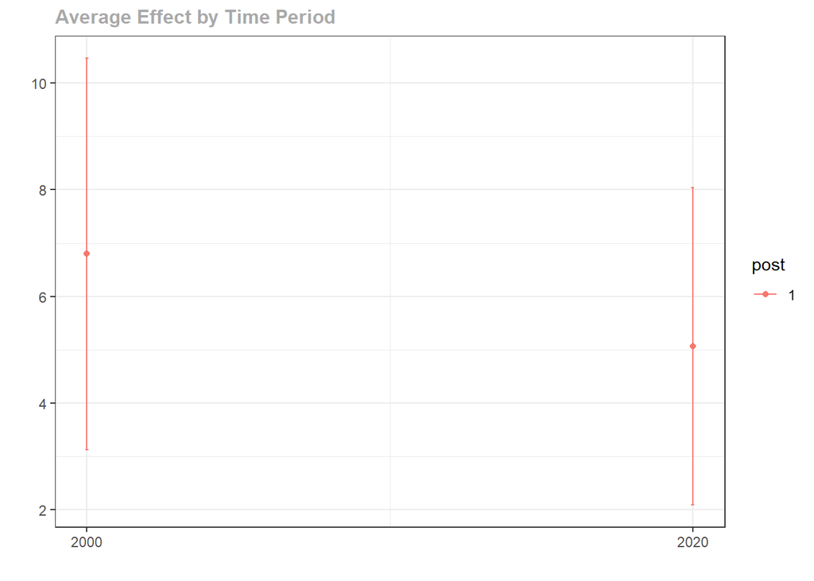

```r
ggdid(cef_cond)
```

1975、2000、2010、2020の４時点パネル

```r
#data_VCF_long$firstyear <- data_VCF_long$jp_1sttreat
#data_VCF_long$firstyear <- data_VCF_long$wb_1sttreat
data_VCF_long$firstyear <- data_VCF_long$jpwb_1sttreat


data_VCF_long2 <- data_VCF_long %>%
  filter(year == 1975 | year == 2000 | year == 2010 | year == 2020) %>%
  mutate(
    year = as.numeric(year),
    firsttreat = case_when(
          firstyear > 0 & firstyear < 2000 ~ 2000,
          firstyear >= 2000 & firstyear < 2010 ~ 2010,
          firstyear >= 2010 ~ 2020,
          TRUE ~ 0
        )
    )

summary(data_VCF_long2)
```

```
##     GID_2             NAME_1.x           NAME_2.x           NAME_1.y
##  Length:2664        Length:2664        Length:2664        Length:2664
##  Class :character   Class :character   Class :character   Class :character
##  Mode  :character   Mode  :character   Mode  :character   Mode  :character
##
##
##
##
##    NAME_2.y           jp_all_num       jp_all_tr       jp_all_cost
##  Length:2664        Min.   :0.0000   Min.   :0.0000   Min.   :  0.00
##  Class :character   1st Qu.:0.0000   1st Qu.:0.0000   1st Qu.:  0.00
##  Mode  :character   Median :0.0000   Median :0.0000   Median :  0.00
##                     Mean   :0.6381   Mean   :0.4174   Mean   : 80.36
##                     3rd Qu.:1.0000   3rd Qu.:1.0000   3rd Qu.:128.20
##                     Max.   :4.0000   Max.   :1.0000   Max.   :423.00
##
##    wb_all_num       wb_all_tr       wb_all_cost      jpwb_all_num
##  Min.   :0.0000   Min.   :0.0000   Min.   :  0.00   Min.   :0.000
##  1st Qu.:0.0000   1st Qu.:0.0000   1st Qu.:  0.00   1st Qu.:0.000
##  Median :1.0000   Median :1.0000   Median : 33.00   Median :1.000
##  Mean   :0.9249   Mean   :0.5616   Mean   : 70.47   Mean   :1.563
##  3rd Qu.:1.0000   3rd Qu.:1.0000   3rd Qu.:124.00   3rd Qu.:3.000
##  Max.   :4.0000   Max.   :1.0000   Max.   :256.00   Max.   :6.000
##
##   jpwb_all_tr     jpwb_all_cost   jpwb_all_4type      jp_1sttreat
##  Min.   :0.0000   Min.   :  0.0   Length:2664        Min.   :   0.0
##  1st Qu.:0.0000   1st Qu.:  0.0   Class :character   1st Qu.:   0.0
##  Median :1.0000   Median :122.2   Mode  :character   Median :   0.0
##  Mean   :0.7447   Mean   :150.8                      Mean   : 836.4
##  3rd Qu.:1.0000   3rd Qu.:253.0                      3rd Qu.:1997.0
##  Max.   :1.0000   Max.   :588.0                      Max.   :2018.0
##
##   wb_1sttreat   jpwb_1sttreat   STjp_all_num     STjp_all_tr
##  Min.   :   0   Min.   :   0   Min.   :0.0000   Min.   :0.0000
##  1st Qu.:   0   1st Qu.:   0   1st Qu.:0.0000   1st Qu.:0.0000
##  Median :1979   Median :1983   Median :1.0000   Median :1.0000
##  Mean   :1116   Mean   :1483   Mean   :0.9805   Mean   :0.5165
##  3rd Qu.:1985   3rd Qu.:1995   3rd Qu.:2.0000   3rd Qu.:1.0000
##  Max.   :2018   Max.   :2018   Max.   :5.0000   Max.   :1.0000
##
```

[output cut: 57 more lines]

```
##  Min.   :-2.761   Min.   :-2.812   Min.   :1.910   Min.   :0.0000
##  1st Qu.: 3.398   1st Qu.: 2.911   1st Qu.:4.262   1st Qu.:0.0000
##  Median : 3.447   Median : 2.982   Median :4.571   Median :1.0000
##  Mean   : 3.374   Mean   : 2.909   Mean   :4.600   Mean   :0.7447
##  3rd Qu.: 3.484   3rd Qu.: 3.039   3rd Qu.:4.940   3rd Qu.:1.0000
##  Max.   : 3.579   Max.   : 3.264   Max.   :6.362   Max.   :1.0000
##  NA's   :5        NA's   :38
##    firstyear      firsttreat
##  Min.   :   0   Min.   :   0
##  1st Qu.:   0   1st Qu.:   0
##  Median :1983   Median :2000
##  Mean   :1483   Mean   :1492
##  3rd Qu.:1995   3rd Qu.:2000
##  Max.   :2018   Max.   :2020
##
```

```r
table(data_VCF_long2$firsttreat)
```

```
##
##    0 2000 2010 2020
##  680 1620  116  248
```

```r
out <- att_gt(yname = "forest",
              gname = "firsttreat",
              idname = "ID_dist",
              tname = "year",
              xformla = ~ prec + tmmx + tmmn + pop,
              data = data_VCF_long2,
              est_method = "reg")

summary(out)
```

```
##
## Call:
## att_gt(yname = "forest", tname = "year", idname = "ID_dist",
##     gname = "firsttreat", xformla = ~prec + tmmx + tmmn + pop,
##     data = data_VCF_long2, est_method = "reg")
##
## Reference: Callaway, Brantly and Pedro H.C. Sant'Anna.  "Difference-in-Differences with Multiple Time Periods." Forthcoming at the Journal of Econometrics <https://arxiv.org/abs/1803.09015>, 2020.
##
## Group-Time Average Treatment Effects:
##  Group Time ATT(g,t) Std. Error [95% Simult.  Conf. Band]
##   2000 2000   4.5561     2.6519       -2.1365     11.2486
##   2000 2010   6.2349     2.6226       -0.3837     12.8536
##   2000 2020   6.4042     2.7272       -0.4786     13.2870
##   2010 2000 -10.2004     3.8602      -19.9425     -0.4582 *
##   2010 2010   0.3301     0.8350       -1.7773      2.4375
##   2010 2020   0.1220     0.4898       -1.1141      1.3580
##   2020 2000  -6.5265     2.4130      -12.6163     -0.4367 *
##   2020 2010   0.6148     0.6114       -0.9282      2.1578
##   2020 2020   1.3298     0.5565       -0.0746      2.7342
## ---
## Signif. codes: `*' confidence band does not cover 0
##
## P-value for pre-test of parallel trends assumption:  0.00235
## Control Group:  Never Treated,  Anticipation Periods:  0
## Estimation Method:  Outcome Regression
```

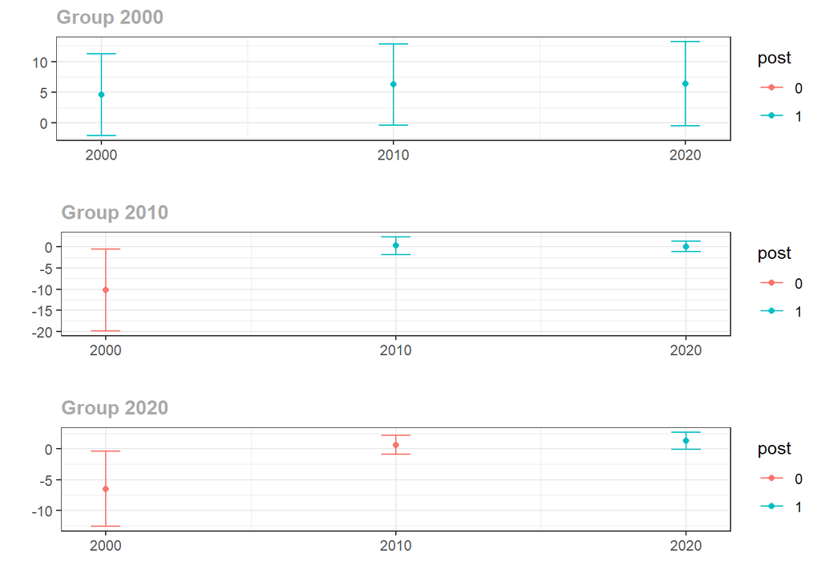

```r
ggdid(out)
```

```r
#Error?
es <- aggte(out, type = "dynamic")
summary(es)
```

```
##
## Call:
## aggte(MP = out, type = "dynamic")
##
## Reference: Callaway, Brantly and Pedro H.C. Sant'Anna.  "Difference-in-Differences with Multiple Time Periods." Forthcoming at the Journal of Econometrics <https://arxiv.org/abs/1803.09015>, 2020.
##
##
## Overall ATT:
##     ATT Std. Error     [95%  Conf. Int.]
##  5.3788     2.3467    0.7793      9.9783 *
##
##
## Dynamic Effects:
##  event time     ATT Std. Error [95% Simult.  Conf. Band]
##         -20 -6.5265     2.2480      -11.7007     -1.3524 *
##         -10 -2.8318     1.4204       -6.1011      0.4375
##           0  3.9057     1.9991       -0.6956      8.5069
##          10  5.8264     2.5006        0.0709     11.5820 *
##          20  6.4042     2.7054        0.1773     12.6311 *
## ---
## Signif. codes: `*' confidence band does not cover 0
##
## Control Group:  Never Treated,  Anticipation Periods:  0
## Estimation Method:  Outcome Regression
```

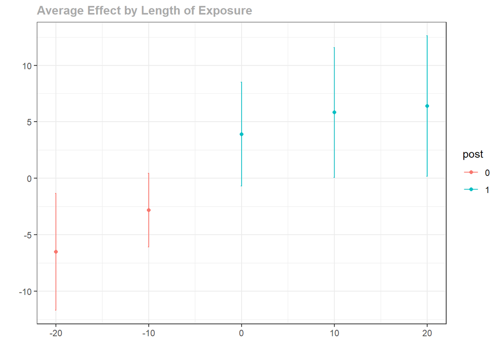

```r
ggdid(es)
```

```r
group_effects <- aggte(out, type = "group")
summary(group_effects)
```

```
##
## Call:
## aggte(MP = out, type = "group")
##
## Reference: Callaway, Brantly and Pedro H.C. Sant'Anna.  "Difference-in-Differences with Multiple Time Periods." Forthcoming at the Journal of Econometrics <https://arxiv.org/abs/1803.09015>, 2020.
##
##
## Overall ATT:
##     ATT Std. Error     [95%  Conf. Int.]
##  4.8596     2.1322    0.6806      9.0386 *
##
##
## Group Effects:
##  group    ATT Std. Error [95% Simult.  Conf. Band]
##   2000 5.7317     2.5967        0.0421     11.4213 *
##   2010 0.2260     0.6694       -1.2407      1.6927
##   2020 1.3298     0.5186        0.1936      2.4660 *
## ---
## Signif. codes: `*' confidence band does not cover 0
##
## Control Group:  Never Treated,  Anticipation Periods:  0
## Estimation Method:  Outcome Regression
```

2000、2010、2020の3時点パネル

```r
#data_VCF_long$firstyear <- data_VCF_long$jp_1sttreat
#data_VCF_long$firstyear <- data_VCF_long$wb_1sttreat
data_VCF_long$firstyear <- data_VCF_long$jpwb_1sttreat


data_VCF_long2 <- data_VCF_long %>%
  filter(year == 2000 | year == 2010 | year == 2020) %>%
  mutate(
    year = as.numeric(year),
    firsttreat = case_when(
          firstyear > 0 & firstyear < 2000 ~ 2000,
          firstyear >= 2000 & firstyear < 2010 ~ 2010,
          firstyear >= 2010 ~ 2020,
          TRUE ~ 0
        )
    )

summary(data_VCF_long2)
```

```
##     GID_2             NAME_1.x           NAME_2.x           NAME_1.y
##  Length:1998        Length:1998        Length:1998        Length:1998
##  Class :character   Class :character   Class :character   Class :character
##  Mode  :character   Mode  :character   Mode  :character   Mode  :character
##
##
##
##
##    NAME_2.y           jp_all_num       jp_all_tr       jp_all_cost
##  Length:1998        Min.   :0.0000   Min.   :0.0000   Min.   :  0.00
##  Class :character   1st Qu.:0.0000   1st Qu.:0.0000   1st Qu.:  0.00
##  Mode  :character   Median :0.0000   Median :0.0000   Median :  0.00
##                     Mean   :0.6381   Mean   :0.4174   Mean   : 80.36
##                     3rd Qu.:1.0000   3rd Qu.:1.0000   3rd Qu.:128.20
##                     Max.   :4.0000   Max.   :1.0000   Max.   :423.00
##
##    wb_all_num       wb_all_tr       wb_all_cost      jpwb_all_num
##  Min.   :0.0000   Min.   :0.0000   Min.   :  0.00   Min.   :0.000
##  1st Qu.:0.0000   1st Qu.:0.0000   1st Qu.:  0.00   1st Qu.:0.000
##  Median :1.0000   Median :1.0000   Median : 33.00   Median :1.000
##  Mean   :0.9249   Mean   :0.5616   Mean   : 70.47   Mean   :1.563
##  3rd Qu.:1.0000   3rd Qu.:1.0000   3rd Qu.:124.00   3rd Qu.:3.000
##  Max.   :4.0000   Max.   :1.0000   Max.   :256.00   Max.   :6.000
##
##   jpwb_all_tr     jpwb_all_cost   jpwb_all_4type      jp_1sttreat
##  Min.   :0.0000   Min.   :  0.0   Length:1998        Min.   :   0.0
##  1st Qu.:0.0000   1st Qu.:  0.0   Class :character   1st Qu.:   0.0
##  Median :1.0000   Median :122.2   Mode  :character   Median :   0.0
##  Mean   :0.7447   Mean   :150.8                      Mean   : 836.4
##  3rd Qu.:1.0000   3rd Qu.:253.0                      3rd Qu.:1997.0
##  Max.   :1.0000   Max.   :588.0                      Max.   :2018.0
##
##   wb_1sttreat   jpwb_1sttreat   STjp_all_num     STjp_all_tr
##  Min.   :   0   Min.   :   0   Min.   :0.0000   Min.   :0.0000
##  1st Qu.:   0   1st Qu.:   0   1st Qu.:0.0000   1st Qu.:0.0000
##  Median :1979   Median :1983   Median :1.0000   Median :1.0000
##  Mean   :1116   Mean   :1483   Mean   :0.9805   Mean   :0.5165
##  3rd Qu.:1985   3rd Qu.:1995   3rd Qu.:2.0000   3rd Qu.:1.0000
##  Max.   :2018   Max.   :2018   Max.   :5.0000   Max.   :1.0000
##
```

[output cut: 57 more lines]

```
##  Min.   :-2.761   Min.   :-2.812   Min.   :1.910   Min.   :0.0000
##  1st Qu.: 3.404   1st Qu.: 2.930   1st Qu.:4.200   1st Qu.:0.0000
##  Median : 3.452   Median : 2.996   Median :4.537   Median :1.0000
##  Mean   : 3.377   Mean   : 2.917   Mean   :4.569   Mean   :0.7447
##  3rd Qu.: 3.490   3rd Qu.: 3.048   3rd Qu.:4.944   3rd Qu.:1.0000
##  Max.   : 3.579   Max.   : 3.264   Max.   :6.275   Max.   :1.0000
##  NA's   :2        NA's   :24
##    firstyear      firsttreat
##  Min.   :   0   Min.   :   0
##  1st Qu.:   0   1st Qu.:   0
##  Median :1983   Median :2000
##  Mean   :1483   Mean   :1492
##  3rd Qu.:1995   3rd Qu.:2000
##  Max.   :2018   Max.   :2020
##
```

```r
table(data_VCF_long2$firsttreat)
```

```
##
##    0 2000 2010 2020
##  510 1215   87  186
```

```r
out <- att_gt(yname = "forest",
              gname = "firsttreat",
              idname = "ID_dist",
              tname = "year",
              xformla = ~ prec + tmmx + tmmn + pop ,
              data = data_VCF_long2,
              est_method = "reg")
summary(out)
```

```
##
## Call:
## att_gt(yname = "forest", tname = "year", idname = "ID_dist",
##     gname = "firsttreat", xformla = ~prec + tmmx + tmmn + pop,
##     data = data_VCF_long2, est_method = "reg")
##
## Reference: Callaway, Brantly and Pedro H.C. Sant'Anna.  "Difference-in-Differences with Multiple Time Periods." Forthcoming at the Journal of Econometrics <https://arxiv.org/abs/1803.09015>, 2020.
##
## Group-Time Average Treatment Effects:
##  Group Time ATT(g,t) Std. Error [95% Simult.  Conf. Band]
##   2010 2010   0.3301     0.8836       -1.7567      2.4168
##   2010 2020   0.1220     0.5167       -1.0983      1.3422
##   2020 2010   0.6148     0.5643       -0.7180      1.9476
##   2020 2020   1.3298     0.5832       -0.0475      2.7070
## ---
## Signif. codes: `*' confidence band does not cover 0
##
## P-value for pre-test of parallel trends assumption:  0.30116
## Control Group:  Never Treated,  Anticipation Periods:  0
## Estimation Method:  Outcome Regression
```

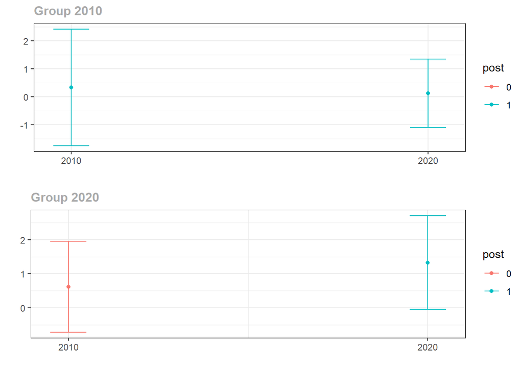

```r
ggdid(out)
```

```r
#Error?
es <- aggte(out, type = "dynamic")
summary(es)
```

```
##
## Call:
## aggte(MP = out, type = "dynamic")
##
## Reference: Callaway, Brantly and Pedro H.C. Sant'Anna.  "Difference-in-Differences with Multiple Time Periods." Forthcoming at the Journal of Econometrics <https://arxiv.org/abs/1803.09015>, 2020.
##
##
## Overall ATT:
##     ATT Std. Error     [95%  Conf. Int.]
##  0.5666     0.3863   -0.1906      1.3238
##
##
## Dynamic Effects:
##  event time    ATT Std. Error [95% Simult.  Conf. Band]
##         -10 0.6148     0.5878       -0.7274      1.9571
##           0 1.0112     0.4355        0.0166      2.0058 *
##          10 0.1220     0.4929       -1.0036      1.2475
## ---
## Signif. codes: `*' confidence band does not cover 0
##
## Control Group:  Never Treated,  Anticipation Periods:  0
## Estimation Method:  Outcome Regression
```

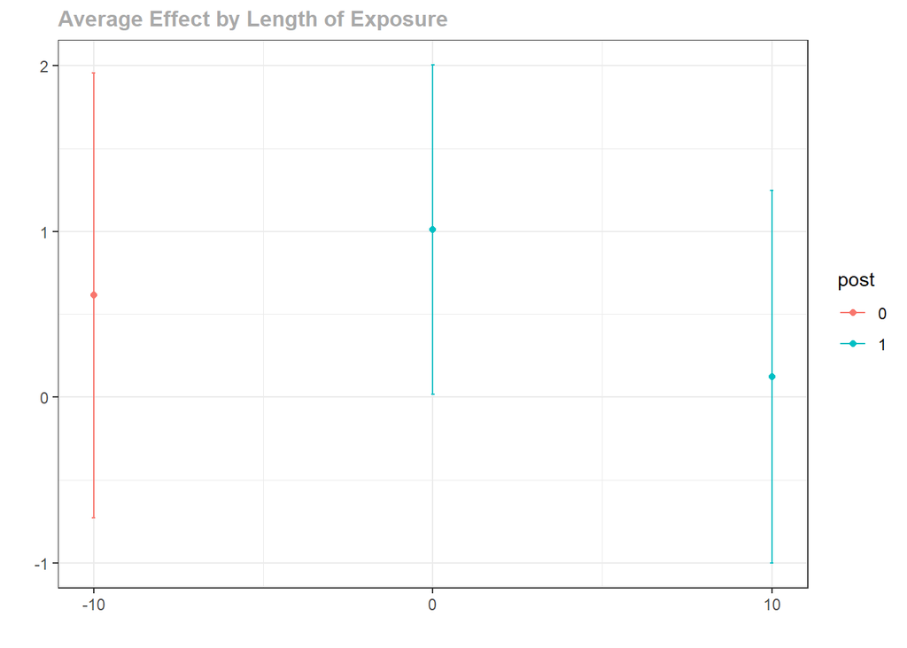

```r
ggdid(es)
```

```r
group_effects <- aggte(out, type = "group")
summary(group_effects)
```

```
##
## Call:
## aggte(MP = out, type = "group")
##
## Reference: Callaway, Brantly and Pedro H.C. Sant'Anna.  "Difference-in-Differences with Multiple Time Periods." Forthcoming at the Journal of Econometrics <https://arxiv.org/abs/1803.09015>, 2020.
##
##
## Overall ATT:
##    ATT Std. Error     [95%  Conf. Int.]
##  0.978     0.3795    0.2342      1.7219 *
##
##
## Group Effects:
##  group    ATT Std. Error [95% Simult.  Conf. Band]
##   2010 0.2260     0.6544       -1.1786      1.6307
##   2020 1.3298     0.4960        0.2652      2.3944 *
## ---
## Signif. codes: `*' confidence band does not cover 0
##
## Control Group:  Never Treated,  Anticipation Periods:  0
## Estimation Method:  Outcome Regression
```